## Code for reading in the dataset and/or processing the data

## Unzip download file

setwd(“C:/Users/gregg.abramovich/Desktop/R Notes!”) unzip(“repdata-data-activity.zip”)

## prep required packages

library(data.table) library(ggplot2) library(knitr) library(plyr) library(lattice)

## When writing code chunks in the R markdown document, always use echo = TRUE so that someone else will be able to read the code.

opts_chunk$set(echo = TRUE, results = ‘hold’) activityDataSet = read.csv(“activity.csv”)

## variables:

## steps: Number of steps taking in a 5-minute interval (missing values are coded as NA)

## date: The date on which the measurement was taken in YYYY-MM-DD format

## interval: Identifier for the 5-minute interval in which measurement was taken

## need to make sure the date variable is converted to the date datatype

activityDataSet$date <- as.Date(activityDataSet$date)

## str(activityDataSet)

## ‘data.frame’: 17568 obs. of 3 variables:

## $ steps : int NA NA NA NA NA NA NA NA NA NA …

## $ date : Date, format: “2012-10-01” “2012-10-01” “2012-10-01” “2012-10-01” …

## $ interval: int 0 5 10 15 20 25 30 35 40 45 …

## date is now of datatype date and steps and interval are of the int datatype

## Histogram of the total number of steps taken each day

## Sum up number of steps occuring on each day

totalStepsPerDay <- aggregate(steps ~ date, activityDataSet, sum) totalStepsPerDay <- data.frame(totalStepsPerDay) ##convert to data frame for grpahing package ##> str(totalStepsPerDay) ##‘data.frame’: 53 obs. of 2 variables: ## $ date : Date, format: “2012-10-02” “2012-10-03” “2012-10-04” “2012-10-05” … ## $ steps: int 126 11352 12116 13294 15420 11015 12811 9900 10304 17382 …

## Histogram of total of steps per day, with NA’s

qplot(steps, data = totalStepsPerDay, geom = “histogram”,binwidth = 500,xlab = “Total # of Daily Steps”, ylab = “Frequency of Times Per Day”, y = ..density.., fill = I(“white”), colour = I(“black”)) + stat_density(geom = “line”) ##This displays the graph:

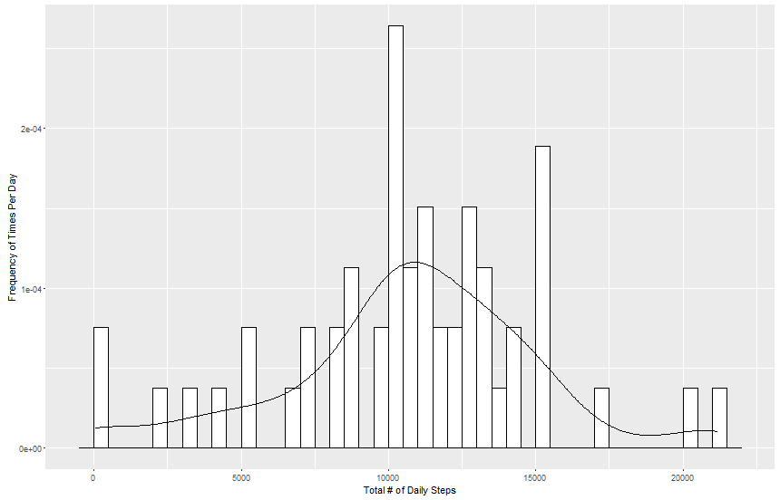

## Calculate mean daily number of steps

mean(totalStepsPerDay$steps) ##[1] 10766.19 ## Calculate median daily number of steps median(totalStepsPerDay$steps) ##[1] 10765

## What is the average daily activity pattern?

## Break down average number of steps over 5 minute intervals during measured period (24 hours)

## mean steps over a list of grouping elements (which is the activity dataset interval) coerced to factors with BY

stepsPerInterval <- aggregate(activityDataSet$steps,by = list(interval = activityDataSet$interval),FUN=mean, na.rm=TRUE)

## > str(stepsPerInterval)

## ‘data.frame’: 288 obs. of 2 variables:

## $ interval: int 0 5 10 15 20 25 30 35 40 45 …

## $ x : num 1.717 0.3396 0.1321 0.1509 0.0755 …

colnames(stepsPerInterval) <- c(“interval”, “steps”) ggplot(stepsPerInterval, aes(x=interval, y=steps)) + geom_line(color=I(“black”), size=1) + labs(title=“Daily Activity Pattern”, x=“5 minute intervals”, y=“Number of steps counted”)

## This displays the graph:

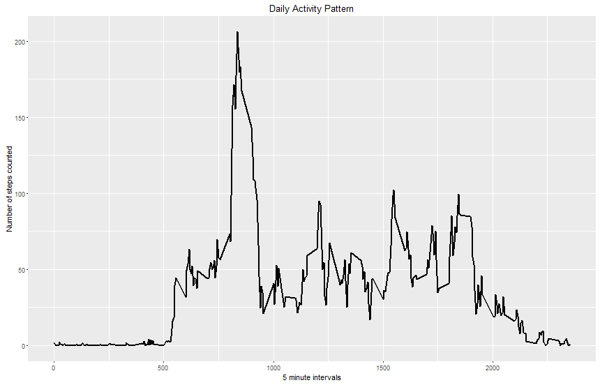

## Which 5 minute interval, on average across all days in the dataset contains the nax number of steps

max(stepsPerInterval$steps) ##[1] 206.1698 This is our maximum number os steps

which.max(stepsPerInterval$steps) ##[1] 104 ##This gives us the 104th record which is: ##104 835 206.1698113, giving us the interval at the 8.35 hour mark

## Imputing missing values

## =======================

## Note that there are a number of days/intervals where there are missing values (coded as NA).

## The presence of missing days may introduce bias into some calculations or summaries of the data.

## calculate total number of missing values in the dataset

missingNaVals <- sum(is.na(activityDataSet$steps)) ## This gives us ##[1] 2304

## Devise a strategy for filling in all of the missing values in the dataset.

## The strategy does not need to be sophisticated. For example, you could use the mean/median for that day, or the mean for that 5-minute interval, etc.

## Function that calculates mean steps for a each interval:

getMeanStepsPerInterval <- function(interval){ stepsPerInterval[stepsPerInterval$interval==interval,“steps”]}

## make a new dataset with the NA’s filled in

## ============================================

activityDataSetFilled <- activityDataSet ##copy our original dataset ## Filling the missing values with the mean for that 5-minute interval

## keep a count of how many rows we looped thorugh in our dataset. Loop through each row of the dataset until we’ve gone through all rows (nrow)

## whereever we find our variable steps has an NA value (is.na) and if this is the case, then we call our getMeanStepsPerInterval

## function passing in the particular interval number, and then pulling out the mean value via stepsPerInterval for the given interval

rowcount = 0 for (i in 1:nrow(activityDataSetFilled)) { if (is.na(activityDataSetFilled[i,“steps”])) { activityDataSetFilled[i,“steps”] <- getMeanStepsPerInterval(activityDataSetFilled[i,“interval”]) rowcount = rowcount + 1 } } ##when we run rowcount the first time it gives us: ##> rowcount ##[1] 2304 ##which indicates that we looped through 2304 rows ##And if we run it again it then displays: ##> rowcount ##[1] 0 ##indicating there are no further NA entries to fill in

## Histogram of total of steps per day, with NA’s filled with mean values

totalStepsPerDayFilled <- aggregate(steps ~ date, activityDataSetFilled, sum) totalStepsPerDayFilled <- data.frame(totalStepsPerDayFilled) ##convert to data frame for grpahing package

qplot(steps, data = totalStepsPerDayFilled, geom = “histogram”,binwidth = 500,xlab = “Total # of Daily Steps”, ylab = “Frequency of Times Per Day”, y = ..density.., fill = I(“white”), colour = I(“black”)) + stat_density(geom = “line”)

## This displays the graph:

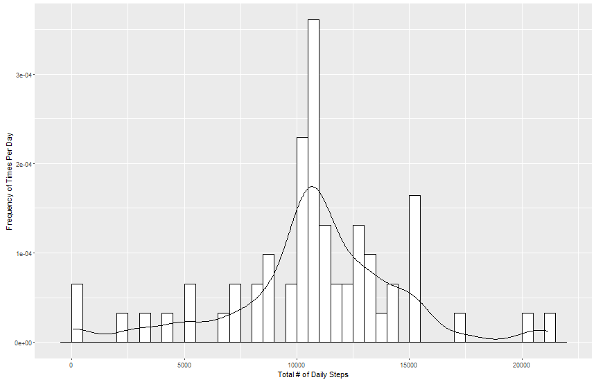

## Calculate and report the mean and median total number of steps taken per day

mean(totalStepsPerDayFilled$steps) ##[1] 10766.19 median(totalStepsPerDayFilled$steps) ##[1] 10766.19 ##Do these values differ from the first part of the assignment? ## The mean is the same, but the median increased to the same as the mean value. You can also see the with a desnity plot, the curve is steeper and ##moves more towards the middle. Filling in the values with mean entries, pushes the median towards the mean.

## Are there differences in activity patterns between weekdays and weekends?

## =========================================================================

activityDataSetFilled2 <- activityDataSetFilled

## create a vector of weekdays, this way we can create a new factor variable with 2 levels, weekend and weekday - for the given date.

weekdays1 <- c(‘Monday’, ‘Tuesday’, ‘Wednesday’, ‘Thursday’, ‘Friday’) ##Use `%in%` and `weekdays` to create a logical vector

activityDataSetFilled2$wDay <- c('weekend', 'weekday')[(weekdays(activityDataSetFilled2$date) %in% weekdays1)+1L] ##head(activityDataSetFilled2) ##steps date interval wDay ##1 1.7169811 2012-10-01 0 weekday ##2 0.3396226 2012-10-01 5 weekday

## Finally, make panel plot showing time series of 5-minute interval and average number of steps takes, weekend versus weekdays.

sInt = aggregate(steps ~ interval + wDay, activityDataSetFilled2, mean) xyplot(steps ~ interval | factor(wDay), data = sInt, aspect = 1/2, type = “l”)

## This displays the graph:

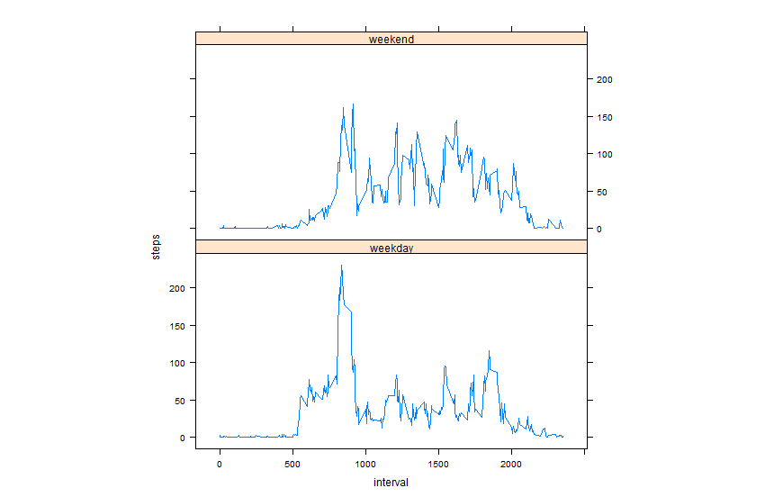